# Model fitting and selection using linear regression

**CASE STUDY**

Low birth weight data: The goal of this study was to identify risk factors associated with giving birth to a low birth weight baby (weighing less than 2500 grams). Data were collected on 189 women, 59 of which had low birth weight babies and 130 of which had normal birth weight babies. Four variables which were thought to be of importance were age, weight of the subject at her last menstrual period, race, and the number of physician visits during the first trimester of pregnancy.

**ID Meaning**  
LOW Low BirthWeight (0 = BirthWeight >= 2500g, 1 = Birth Weight < 2500g)  
AGE Age of the Mother in Years  
LWT Weight in Pounds at the Last Menstrual Period  
RACE Race (1 = White, 2 = Black, 3 = Other)  
SMOKE Smoking Status During Pregnancy (1 = Yes, 0 = No)  
PTL History of Premature Labor (0 = None 1 = One, etc.)  
HT History of Hypertension (1 = Yes, 0 = No)  
UI Presence of Uterine Irritability (1 = Yes, 0 = No)  
FTV Number of Physician Visits During the First Trimester (0 = None, 1 = One, 2 = Two, etc.)  
BWT Birth Weight in Grams

*Use the continuous variable BWT as your response variable.*

**Analysis 1:**  
* Considering the four most clinically important variables previously discussed, i.e., age, weight of the subject at her last menstrual period, race, and the number of physician visits during the first trimester of pregnancy, carry out a model building exercise to determine the best model to describe the data. Based your model building exercise on the AIC and AIC weights. Discuss your results carefully.  
* Use backward elimination procedure to decide which predictor variables can be dropped from the regression model. Control the type I error at = .10 at each stage. Which variables are retained? How does this compare to the results obtained with the AIC?

**Analysis 2:**  
* Consider now the 8 covariates included in the data set (all except Birth Weight in Grams). Repeat the previous model building exercise using the AIC and the AIC weights. Compare the results of both analysis and make a careful discussion. * Use backward elimination procedure to decide which predictor variables can be dropped from the regression model. Control the type I error at = .10 at each stage. Which variables are retained? How does this compare to the results obtained with the AIC?  
Discuss.

**Conclusion:**  
Using the final model selected in the previous model building exercise (based on the AIC) answer the following scientific questions:  
* What scientific insight does your final model offer?  
* Interpret the final model using the estimated coefficients and odd ratios.  
* How confident do you feel about the model you selected? Discuss.

```r
library("pastecs")
library("tidyverse")
library("PerformanceAnalytics")
library("AICcmodavg")
```

**Import dataset**

```r
df <- read.table(file="C:/Users/Nnamdi/Desktop/Bioinformatics/Statistical_methods_for_bioinformatics/part_I/Projects/Project2/lowbwt.dat", header=T)
df$RACE <- as.factor(df$RACE)
df$FTV <- as.factor(df$FTV)
head(df)
```

|  | ID | LOW | AGE | LWT | RACE | SMOKE | PTL | HT | UI | FTV | BWT |
| --- | --- | --- | --- | --- | --- | --- | --- | --- | --- | --- | --- |
| 1 | 85 | 0 | 19 | 182 | 2 | 0 | 0 | 0 | 1 | 0 | 2523 |
| 2 | 86 | 0 | 33 | 155 | 3 | 0 | 0 | 0 | 0 | 3 | 2551 |
| 3 | 87 | 0 | 20 | 105 | 1 | 1 | 0 | 0 | 0 | 1 | 2557 |
| 4 | 88 | 0 | 21 | 108 | 1 | 1 | 0 | 0 | 1 | 2 | 2594 |
| 5 | 89 | 0 | 18 | 107 | 1 | 1 | 0 | 0 | 1 | 0 | 2600 |
| 6 | 91 | 0 | 21 | 124 | 3 | 0 | 0 | 0 | 0 | 0 | 2622 |

**ANALYSIS 1**

**Descriptive statistics**

```r
desc.df <- stat.desc(df[,c("AGE","LWT","RACE","FTV")], basic =T, desc=T)
desc.df
```

|  | AGE | LWT | RACE | FTV |
| --- | --- | --- | --- | --- |
| nbr.val | 189.0000000 | 1.890000e+02 | NA | NA |
| nbr.null | 0.0000000 | 0.000000e+00 | NA | NA |
| nbr.na | 0.0000000 | 0.000000e+00 | NA | NA |
| min | 14.0000000 | 8.000000e+01 | NA | NA |
| max | 45.0000000 | 2.500000e+02 | NA | NA |
| range | 31.0000000 | 1.700000e+02 | NA | NA |
| sum | 4392.0000000 | 2.453500e+04 | NA | NA |
| median | 23.0000000 | 1.210000e+02 | NA | NA |
| mean | 23.2380952 | 1.298148e+02 | NA | NA |
| SE.mean | 0.3854221 | 2.224323e+00 | NA | NA |

[output cut: 4 more lines]

**Exploratory data analysis**

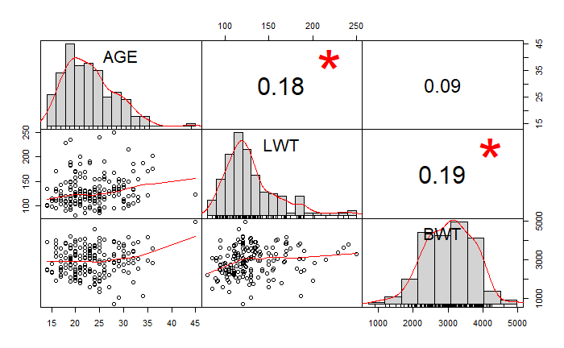

```r
chart.Correlation(df[,c(3,4,11)], histogram=TRUE, pch=19)
```

The birth weight of a new born baby increases with when the age of the mother is 30 and above. This observation is supported by the medical condition called macrosomia. Likewise, the birth weight of the baby increases with an increase in the weight of the mother.

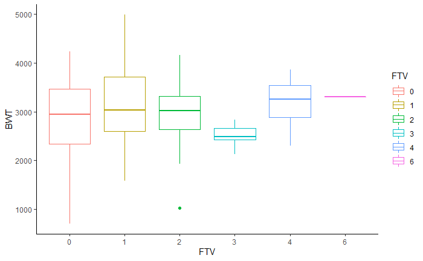

```r
ggplot(df,aes(FTV,BWT,color = FTV))+geom_boxplot() + theme_classic()
```

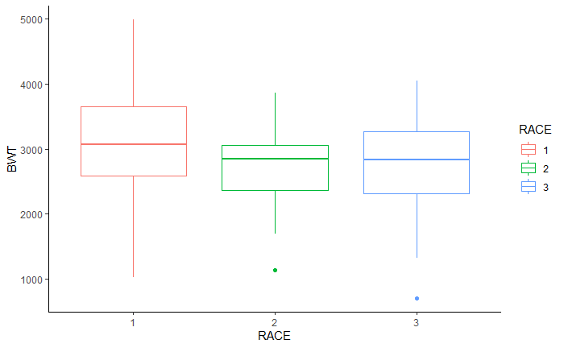

```r
ggplot(df,aes(RACE,BWT,color = RACE))+geom_boxplot() + theme_classic()
```

The plot shows that white women have babies with more birth weight compared to African women or womwn from other ethnicities

**Fitting Models**

```r
mod <- lm(BWT ~ AGE+LWT+RACE+FTV, data=df)
summary (mod)
```

```
Call:
lm(formula = BWT ~ AGE + LWT + RACE + FTV, data = df)

Residuals:
     Min       1Q   Median       3Q      Max
-2072.27  -412.00    66.29   483.13  1835.90

Coefficients:
            Estimate Std. Error t value Pr(>|t|)
(Intercept) 2460.544    326.560   7.535 2.34e-12 ***
AGE           -2.119     10.396  -0.204  0.83869
LWT            4.738      1.896   2.499  0.01335 *
RACE2       -448.680    161.637  -2.776  0.00609 **
RACE3       -217.308    118.051  -1.841  0.06731 .
FTV1         206.201    129.085   1.597  0.11194
FTV2          78.297    149.932   0.522  0.60217
FTV3        -335.867    277.057  -1.212  0.22701
FTV4         292.378    361.302   0.809  0.41946
FTV6         -65.298    751.976  -0.087  0.93090
---
Signif. codes:  0 ‘***’ 0.001 ‘**’ 0.01 ‘*’ 0.05 ‘.’ 0.1 ‘ ’ 1

Residual standard error: 704 on 179 degrees of freedom
Multiple R-squared:  0.112, Adjusted R-squared:  0.06736
F-statistic: 2.509 on 9 and 179 DF,  p-value: 0.009973
```

**Forward Selection using AICc score**

```r
mod.list <- list()
mod.list[[1]] <- lm(BWT ~ AGE+LWT+RACE+FTV, data=df)
mod.list[[2]]<- lm(BWT ~ AGE*FTV+AGE*LWT+AGE*RACE+LWT*RACE+LWT*FTV+RACE*FTV, data = df)
mod.list[[3]] <- lm(BWT ~ LWT+RACE, data=df)
mod.list[[4]] <- lm(BWT ~ AGE+LWT+RACE, data=df)
mod.list[[5]] <- lm(BWT ~ FTV+LWT+RACE, data=df)
mod.list[[6]] <- lm(BWT ~ AGE+LWT+RACE+LWT*RACE, data=df)

mod.aictab=aictab(cand.set = mod.list) ##, modnames = donner.modnames)
```

```
Model names have been supplied automatically in the table
```

```r
mod.aictab
```

```
Model selection based on AICc:

      K    AICc Delta_AICc AICcWt Cum.Wt       LL
Mod3  5 3020.40       0.00   0.67   0.67 -1505.04
Mod4  6 3022.52       2.12   0.23   0.91 -1505.03
Mod5 10 3025.85       5.45   0.04   0.95 -1502.31
Mod6  8 3026.25       5.85   0.04   0.99 -1504.73
Mod1 11 3028.06       7.66   0.01   1.00 -1502.28
Mod2 31 3057.12      36.72   0.00   1.00 -1491.24
```

The model fitted by forward selection technique using AICc score is **BWT ~ AGE + LWT + RACE**.  
Alhough this model did not have the lowest AICc score but then it is logical to include the mother’s age as one of the predictors of the birth weight of a baby because it is known that maternal age influences the birth weight of babies as seen in published articles

**Backward selection using p-value < 0.10**

```r
df.mod <- lm(BWT~AGE+LWT+RACE+FTV, data = df)
summary(df.mod)
```

```
Call:
lm(formula = BWT ~ AGE + LWT + RACE + FTV, data = df)

Residuals:
     Min       1Q   Median       3Q      Max
-2072.27  -412.00    66.29   483.13  1835.90

Coefficients:
            Estimate Std. Error t value Pr(>|t|)
(Intercept) 2460.544    326.560   7.535 2.34e-12 ***
AGE           -2.119     10.396  -0.204  0.83869
LWT            4.738      1.896   2.499  0.01335 *
RACE2       -448.680    161.637  -2.776  0.00609 **
RACE3       -217.308    118.051  -1.841  0.06731 .
FTV1         206.201    129.085   1.597  0.11194
FTV2          78.297    149.932   0.522  0.60217
FTV3        -335.867    277.057  -1.212  0.22701
FTV4         292.378    361.302   0.809  0.41946
FTV6         -65.298    751.976  -0.087  0.93090
---
Signif. codes:  0 ‘***’ 0.001 ‘**’ 0.01 ‘*’ 0.05 ‘.’ 0.1 ‘ ’ 1

Residual standard error: 704 on 179 degrees of freedom
Multiple R-squared:  0.112, Adjusted R-squared:  0.06736
F-statistic: 2.509 on 9 and 179 DF,  p-value: 0.009973
```

**ANALYSIS 2**

```r
names(df)
```

**Descriptive statistics**

```r
df$SMOKE <- as.factor(df$SMOKE)
df$PTL <- as.factor(df$PTL)
df$HT <- as.factor(df$HT)
df$UI <- as.factor(df$UI)
desc.df <- stat.desc(df[,c("AGE","LWT","RACE","SMOKE","PTL","HT","UI","FTV")], basic =T, desc=T)
desc.df
```

[output not shown]

**Exploratory data analysis**

```r
chart.Correlation(df[,-c(1,2,5:10)], histogram=TRUE, pch=19)
```

[output not shown]

The birth weight of a new born baby increases with when the age of the mother is 30 and above. This observation is supported by the medical condition called macrosomia. Likewise, the birth weight of the baby increases with an increase in the weight of the mother.

Boxplots

```r
ggplot(df,aes(RACE,BWT,color = RACE))+geom_boxplot() + theme_classic()
```

[output not shown]

The plot shows that white women have babies with more birth weight compared to African women or womwn from other ethnicities

```r
ggplot(df,aes(SMOKE,BWT,color = SMOKE))+geom_boxplot() + theme_classic()
```

[output not shown]

The barplot shows that women that smoke during pregnancy will likely have give birth to babies with low birth weight.

```r
ggplot(df,aes(PTL,BWT,color = PTL))+geom_boxplot() + theme_classic()
```

[output not shown]

The barplot shows that women with the highest history(3 times) of premature labor had the highest median of birth weight of the newly born babies.

```r
ggplot(df,aes(HT,BWT,color = HT))+geom_boxplot() + theme_classic()
```

[output not shown]

The plot shows that women with hypertension had babies with lower birth weight compared to women without hypertension.

```r
ggplot(df,aes(UI,BWT,color = UI))+geom_boxplot() + theme_classic()
```

[output not shown]

```r
ggplot(df,aes(FTV,BWT,color = FTV))+geom_boxplot() + theme_classic()
```

[output not shown]

**Fitting Models**

```r
mod2 <- lm(BWT ~ AGE+LWT+RACE+SMOKE+PTL+HT+UI+FTV, data=df)
summary (mod2)
```

[output not shown]

**Model building using AIC and AIC weights**

```r
mod.list <- list()
mod.list[[1]] <- lm(BWT ~ AGE+LWT+RACE+SMOKE+PTL+HT+UI+FTV, data=df)
mod.list[[2]]<- lm(BWT ~ LWT+RACE+SMOKE+PTL+HT+UI, data = df)
mod.list[[3]] <- lm(BWT ~ AGE+LWT+RACE+SMOKE+PTL+HT+UI, data = df)
mod.list[[4]] <- lm(BWT ~ LWT*RACE+LWT*SMOKE+LWT*PTL+LWT*HT+LWT*UI, data=df)
mod.list[[5]] <- lm(BWT ~ RACE*SMOKE+RACE*PTL+RACE*HT+RACE*UI, data=df)
mod.list[[6]] <- lm(BWT ~ SMOKE*PTL+SMOKE*HT+SMOKE*UI, data=df)
mod.list[[7]] <- lm(BWT ~ PTL*HT+PTL*UI, data=df)
mod.list[[8]] <- lm(BWT ~ UI*HT, data=df)

mod.aictab=aictab(cand.set = mod.list) ##, modnames = donner.modnames)
mod.aictab
```

[output not shown]

The model fitted by forward selection technique using AICc score is **BWT ~ AGE+LWT+RACE+SMOKE+PTL+HT+UI**.  
Alhough this model did not have the lowest AICc score but then it is logical to include the mother’s age as one of the predictors of the birth weight of a baby because it is known that maternal age influences the birth weight of babies as seen in published articles

**Backward selection using p-value < 0.10**

```r
summary(mod2)  ## full model
```

[output not shown]

remove variables with p-value > 0.1

```r
clean.mod2 <- update(mod2, . ~ . - FTV, data = df)
summary(clean.mod2)
```

[output not shown]

remove more variables with p-value > 0.1

```r
clean.mod3 <- update(clean.mod2, . ~ . - PTL, data = df)
summary(clean.mod3)
```

[output not shown]

The model fitted by backward selection technique using control p-value less than 0.10 is:  
**BWT ~ AGE + LWT + RACE + SMOKE + HT + UI**.  
This model is slightly different from the model fitted with forward selection technique and AICc. Age has a p -value greater than 0.1 but we will include it in the model because it is known that maternal age affects birth weight of babies ( a condition known as Macrosomia)